# TP000- Revisión Estadística

Agustín normand

2 Septiembre 2021

A partir del siguiente [dataset](https://www.kaggle.com/ophi/mpi/data), se solicita trabajar sobre las siguientes consignas:

### 1. Exploración de datos:

Explore y explique en que consiste el dataset utilizando herramientas de exploración de datos.

#### a. Releve las características de los atributos.

```r
str(MPI_subnational)
```

```
## spec_tbl_df [984 × 8] (S3: spec_tbl_df/tbl_df/tbl/data.frame)
##  $ ISO country code                 : chr [1:984] "AFG" "AFG" "AFG" "AFG" ...
##  $ Country                          : chr [1:984] "Afghanistan" "Afghanistan" "Afghanistan" "Afghanistan" ...
##  $ Sub-national region              : chr [1:984] "Badakhshan" "Badghis" "Baghlan" "Balkh" ...
##  $ World region                     : chr [1:984] "South Asia" "South Asia" "South Asia" "South Asia" ...
##  $ MPI National                     : num [1:984] 0.295 0.295 0.295 0.295 0.295 0.295 0.295 0.295 0.295 0.295 ...
##  $ MPI Regional                     : num [1:984] 0.387 0.466 0.3 0.301 0.325 0.313 0.319 0.25 0.245 0.384 ...
##  $ Headcount Ratio Regional         : num [1:984] 67.5 79.3 59.7 55.7 61 65.1 61.4 49.4 47.4 74.6 ...
##  $ Intensity of deprivation Regional: num [1:984] 57.3 58.8 50.3 54.1 53.3 48.1 52 50.6 51.6 51.5 ...
##  - attr(*, "spec")=
##   .. cols(
##   ..   `ISO country code` = col_character(),
##   ..   Country = col_character(),
##   ..   `Sub-national region` = col_character(),
##   ..   `World region` = col_character(),
##   ..   `MPI National` = col_double(),
##   ..   `MPI Regional` = col_double(),
##   ..   `Headcount Ratio Regional` = col_double(),
##   ..   `Intensity of deprivation Regional` = col_double()
##   .. )
##  - attr(*, "problems")=<externalptr>
```

Se trata de un dataset que contiene 984 entradas o filas, y 8 atributos o columnas. Los datos corresponden a Medidas de pobreza publicado por “Oxford Poverty & Human Development Initiative”. Resulta necesario para comprender algunos atributos, conocer del Índice de Pobreza Multidimencional, IPM o MPI. El cual es una medida internacional de pobreza multidimensional aguda que cubre más de 100 países en desarrollo. Dichos atributos son:

- *ISO country code*
  - *Descripción:* ID univoco para los paises.
  - *Tipo de dato:* chr.
- *Country*
  - *Descripción:* Nombre del pais.
  - *Tipo de dato:* chr.
- *Sub-national region*
  - *Descripción:* Región dentro del país.
  - *Tipo de dato:* chr.
- *World region*
  - *Descripción:* Región global.
  - *Tipo de dato:* chr.
- *MPI National*
  - *Descripción:* Puntuación global global del MPI nacional.
  - *Tipo de dato:* num.
- *MPI Regional*
  - *Descripción:* Índice de pobreza multidimensional.
  - *Tipo de dato:* num.
- *Headcount Ratio Regional*
  - *Descripción:* Tasa de recuento de la pobreza (% de la población catalogada como pobre).
  - *Tipo de dato:* num.
- *Intensity of deprivation Regional*
  - *Descripción:* Distancia promedio por debajo de la línea de pobreza de los que figuran como pobres.
  - *Tipo de dato:* num.

#### b. Represente gráficamente la cantidad de ciudades agrupados por región.

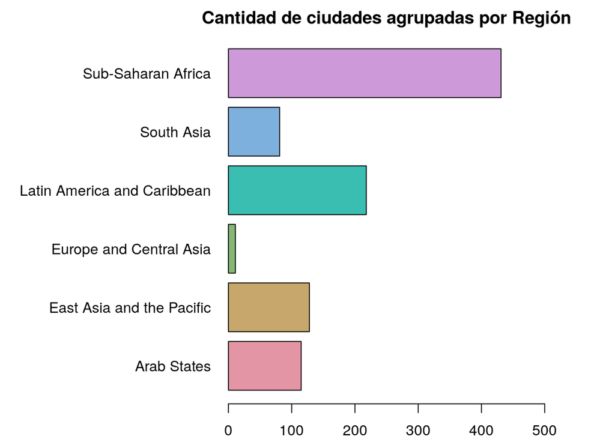

### 2. Medidas de posición:

Calcule las medidas de posición para los atributos numéricos y agrupe los cálculos de acuerdo a la región.

#### a. Ordene los resultados del MPI resultante y concluya al respecto.

Media Aritmetica, Mediana y Moda ordenada por región mundial, del MPI Nacional:

```
## # A tibble: 6 × 4
##   Region                      `Media Aritmetica` Mediana   Moda
##   <chr>                                    <dbl>   <dbl>  <dbl>
## 1 Arab States                             0.111    0.045 0.0140
## 2 East Asia and the Pacific               0.124    0.1   0.066
## 3 Europe and Central Asia                 0.0289   0.008 0.008
## 4 Latin America and Caribbean             0.0543   0.034 0.072
## 5 South Asia                              0.209    0.196 0.295
## 6 Sub-Saharan Africa                      0.332    0.307 0.303
```

Media Aritmetica, Mediana y Moda ordenada por región mundial, del MPI Regional:

```
## # A tibble: 6 × 4
##   Region                      `Media Aritmetica` Mediana  Moda
##   <chr>                                    <dbl>   <dbl> <dbl>
## 1 Arab States                             0.115   0.052  0.006
## 2 East Asia and the Pacific               0.136   0.0995 0.053
## 3 Europe and Central Asia                 0.0253  0.016  0.021
## 4 Latin America and Caribbean             0.0637  0.0375 0.03
## 5 South Asia                              0.220   0.199  0.294
## 6 Sub-Saharan Africa                      0.337   0.333  0.292
```

Media Aritmetica, Mediana y Moda ordenada por región mundial, del Headcount Ratio Regional o porcentaje de gente pobre según el MPI Regional:

```
## # A tibble: 6 × 4
##   Region                      `Media Aritmetica` Mediana  Moda
##   <chr>                                    <dbl>   <dbl> <dbl>
## 1 Arab States                              23.1    12.5    2.2
## 2 East Asia and the Pacific                28.3    23     13.4
## 3 Europe and Central Asia                   6.43    4.1    6.1
## 4 Latin America and Caribbean              14.2     8.95   1.4
## 5 South Asia                               44.1    45.2   65.1
## 6 Sub-Saharan Africa                       61.5    66.6   72
```

Media Aritmetica, Mediana y Moda ordenada por región mundial, del Intensity of Deprivation Regional o distancia promedio a la que se encuentra la gente pobre respecto de la línea de pobreza:

```
##                        Region Media Aritmetica Mediana Moda
## 1                 Arab States         42.65391    40.6 40.6
## 2   East Asia and the Pacific         45.60156    44.7 42.7
## 3     Europe and Central Asia         37.08182    36.0 33.3
## 4 Latin America and Caribbean         41.53871    41.4 39.8
## 5                  South Asia         47.63951    46.6 48.1
## 6          Sub-Saharan Africa         51.87030    50.4 47.3
```

#### b. Grafique las variables y observe su comportamiento.

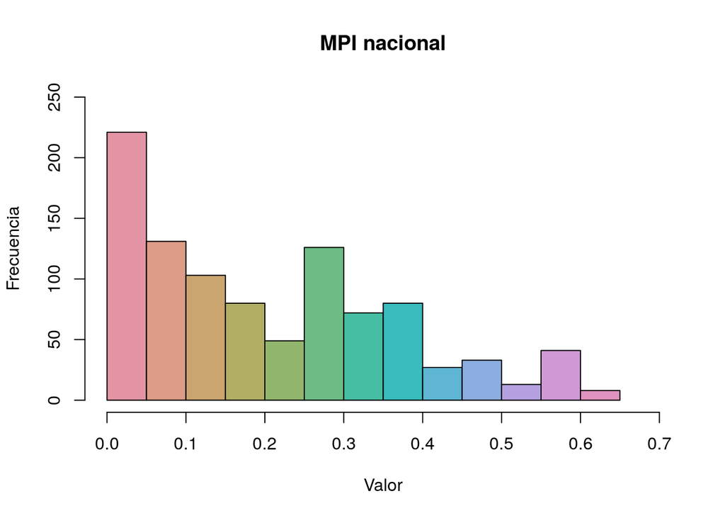

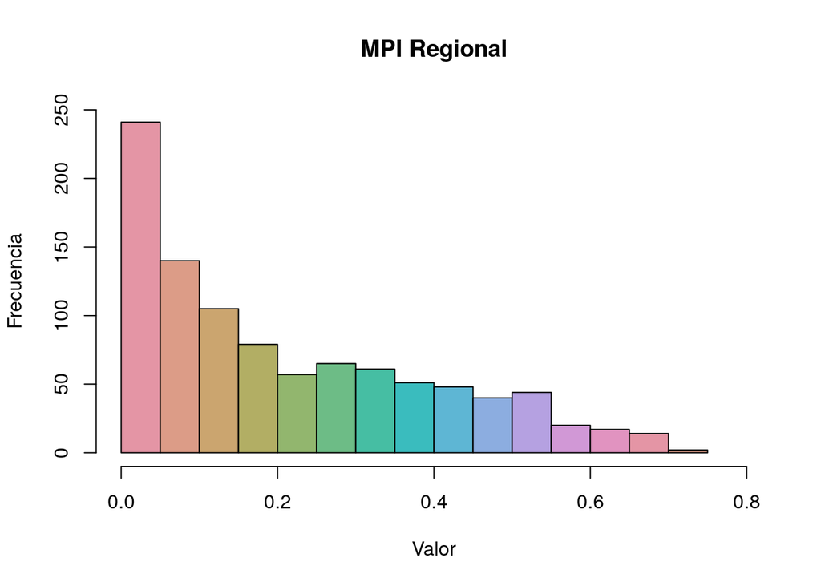

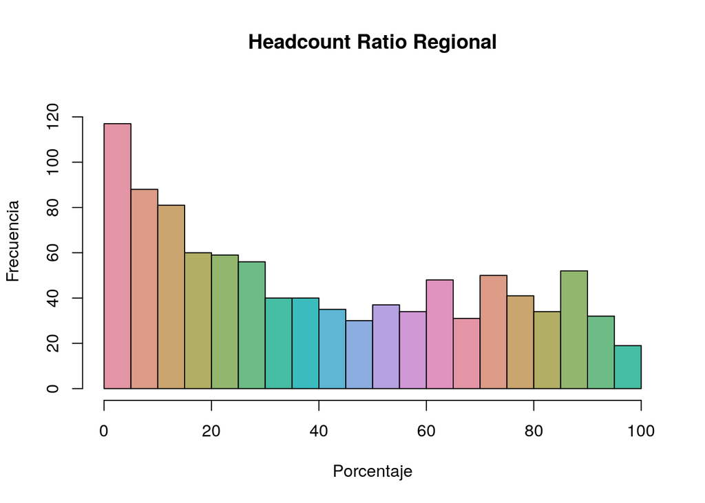

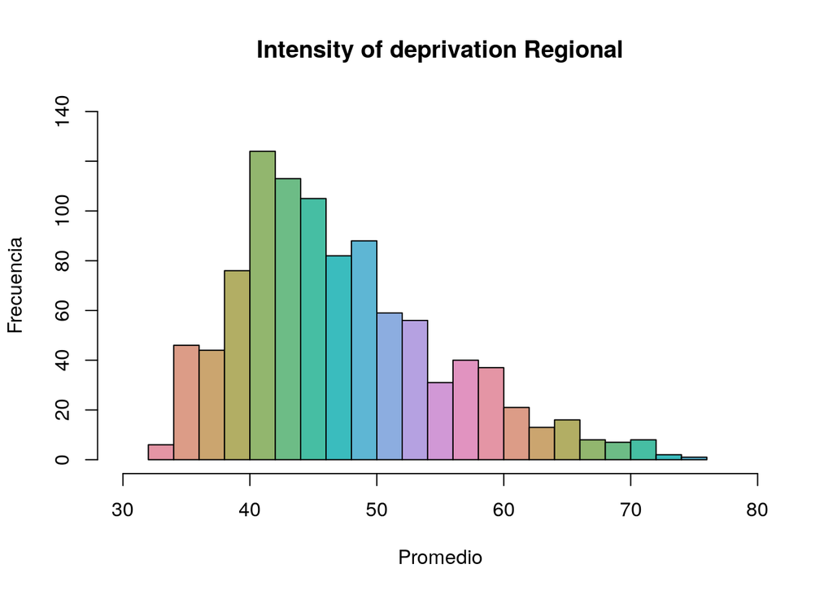

### 3. Medidas de dispersión:

Calcular la desviación estándar, la varianza y el rango para cada una de las variables.

- *MPI National*
  - *Desviación estándar:*

  ```
  ## [1] 0.1602476
  ```

  - *Rango:*

  ```
  ## [1] 0.006 0.605
  ```

  - *Varianza:*

  ```
  ## [1] 0.02567929
  ```

- *MPI Regional*
  - *Desviación estándar:*

  ```
  ## [1] 0.183621
  ```

  - *Rango:*

  ```
  ## [1] 0.000 0.744
  ```

  - *Varianza:*

  ```
  ## [1] 0.03371667
  ```

- *Headcount Ratio Regional*
  - *Desviación estándar:*

  ```
  ## [1] 29.9814
  ```

  - *Rango:*

  ```
  ## [1]  0 99
  ```

  - *Varianza:*

  ```
  ## [1] 898.8845
  ```

- *Intensity of deprivation Regional*
  - *Desviación estándar:*

  ```
  ## [1] NA
  ```

  - *Rango:*

  ```
  ## [1] NA NA
  ```

  - *Varianza:*

  ```
  ## [1] NA
  ```

#### a. Realice diagramas de cajas y scatterplot’s. Documente las conclusiones.

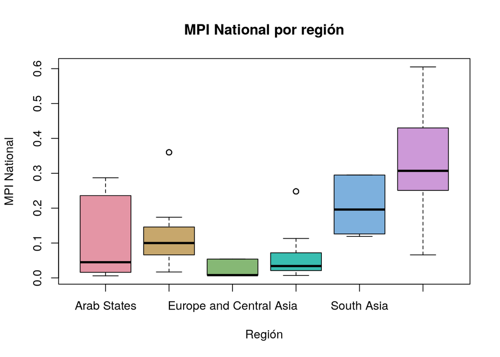

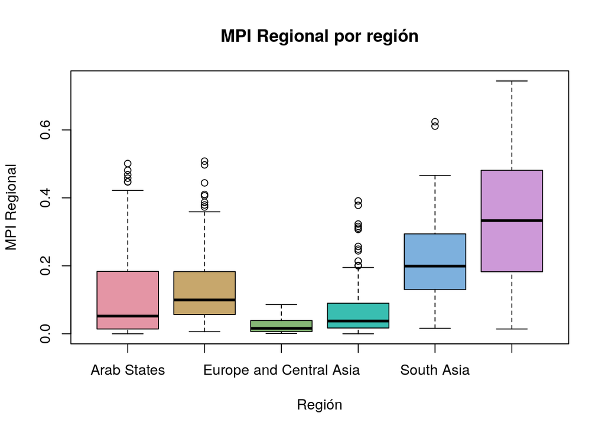

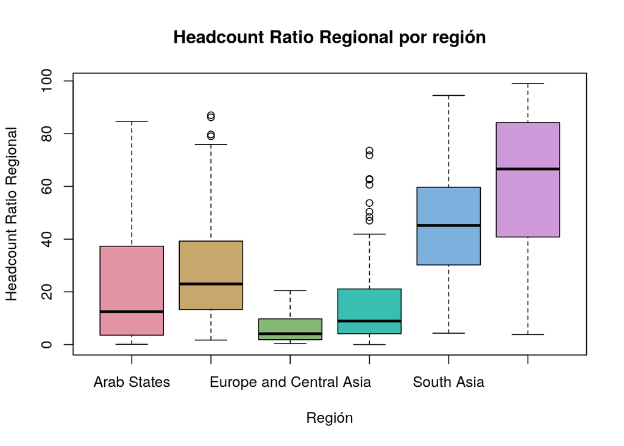

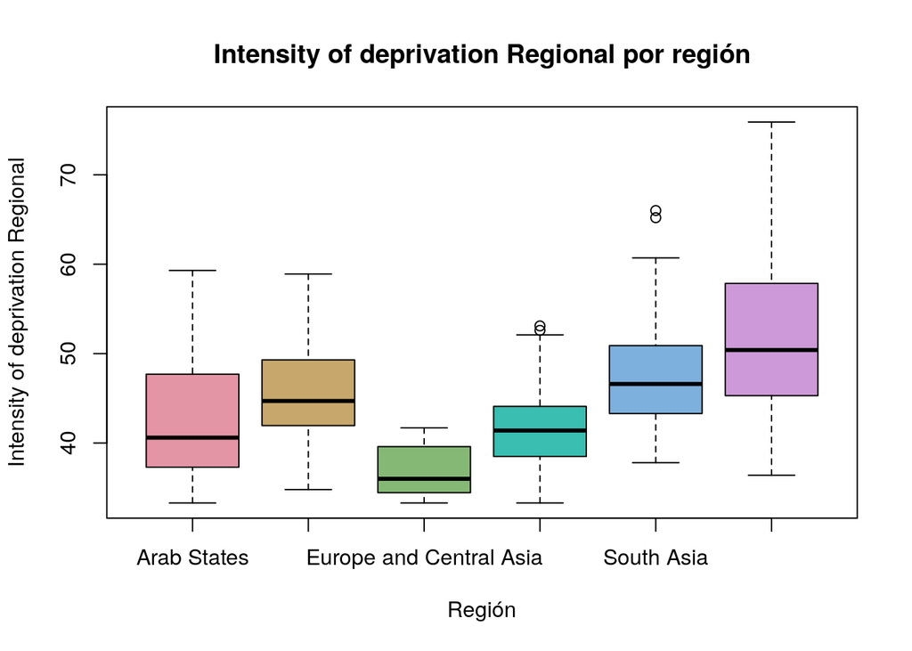

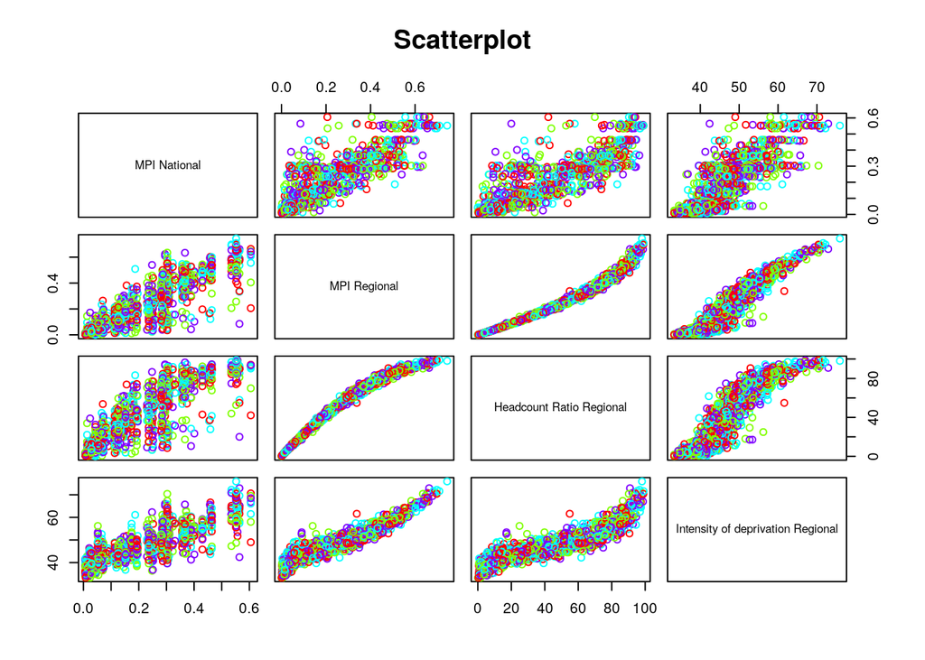

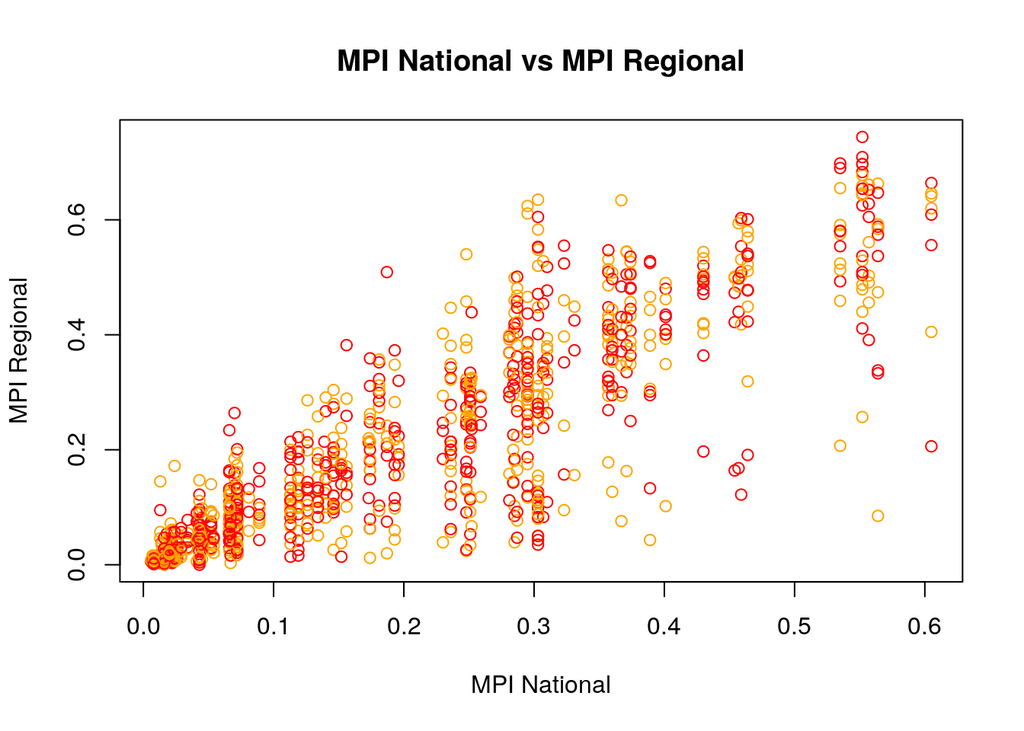

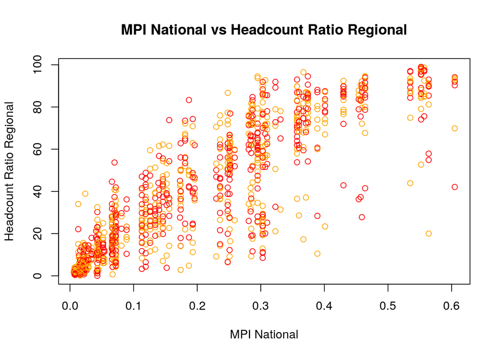

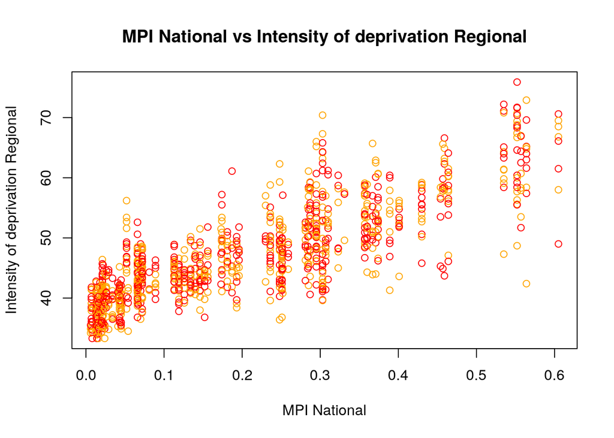

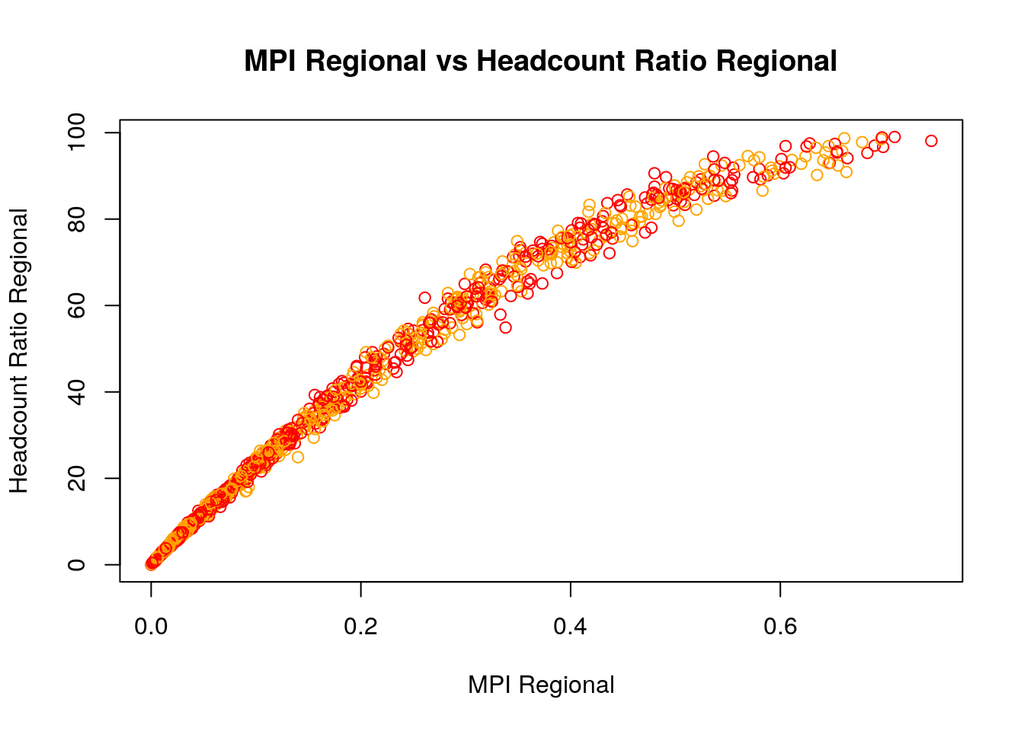

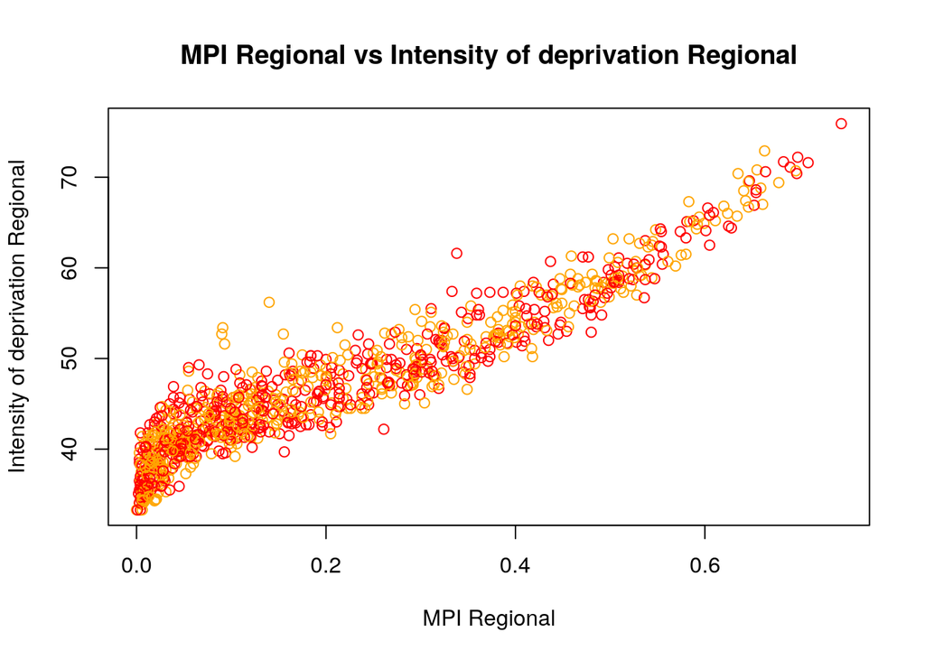

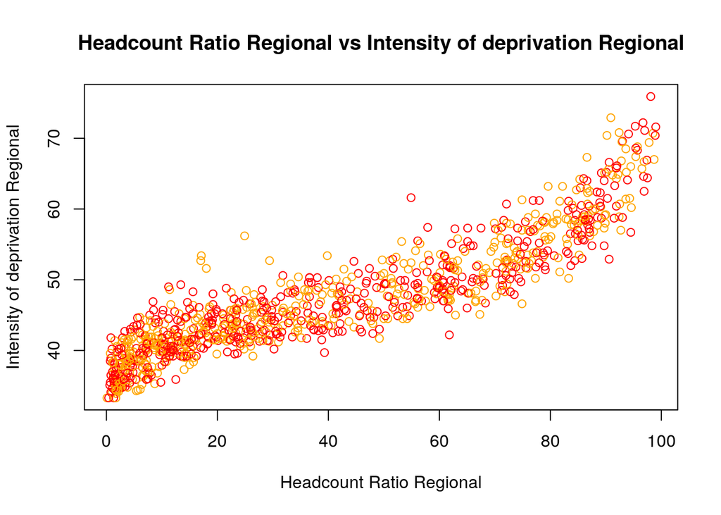